# UL Capstone

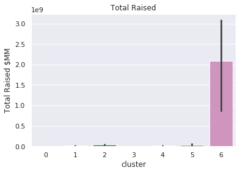

```python
sns.barplot(data=km_df, x='cluster', y='raised_amount_usd')
plt.title('Total Raised')
plt.ylabel('Total Raised $MM')
plt.show();
```

Outliers are FB, TWTR, GOOG, LinkedIn, DropBox, GroupOn, Pinterest, etc.

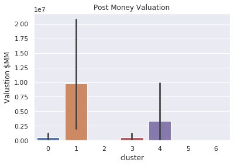

```python
sns.barplot(data=km_df, x='cluster', y='post_money_valuation_usd')
plt.title('Post Money Valuation')
plt.ylabel('Valustion $MM')
plt.show();
```

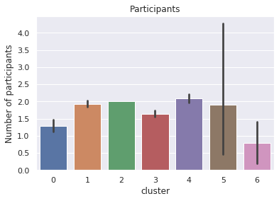

```python
sns.barplot(data=km_df, x='cluster', y='participants')
plt.title('Participants')
plt.ylabel('Number of participants')
plt.show();
```

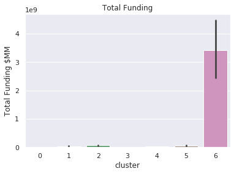

```python
sns.barplot(data=km_df, x='cluster', y='funding_total_usd')
plt.title('Total Funding')
plt.ylabel('Total Funding $MM')
plt.show();
```

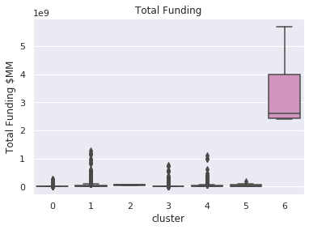

```python
sns.boxplot(data=km_df, x='cluster', y='funding_total_usd')
plt.title('Total Funding')
plt.ylabel('Total Funding $MM')
plt.show();
```

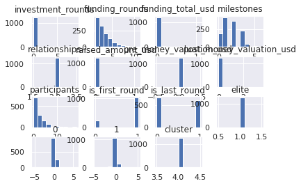

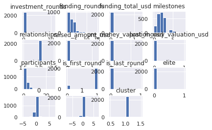

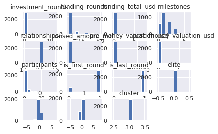

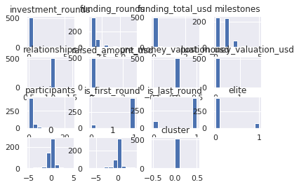

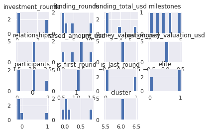

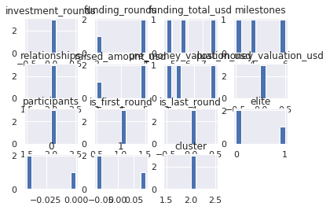

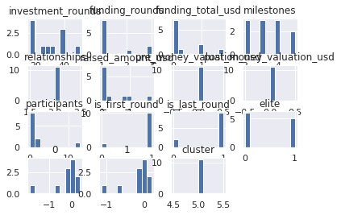

```python
plt.figure(figsize=(20,20))
for i in km_df['cluster'].unique():
    km_df[km_df['cluster']==i].hist()
```

```python
centers = scaler1.inverse_transform(kmeans.cluster_centers_)

centers_df = pd.DataFrame(centers, columns = X1.columns)

centers_df.head()
```

[output not shown]

```python
# Calculate silhouette_score
km_ss = silhouette_score(X1_std, y_pred)
print('The silhouettes score of the K-means solution: {:4f}'.format(km_ss))
```

```
The silhouettes score of the K-means solution: 0.241830
```

## DBSCAN

DBSCAN algorithm, which can find clusters of any arbitrary shape

```python
# Defining the agglomerative clustering
dbscan_cluster = DBSCAN(eps=1, min_samples=5)

# Fit model
dclusters = dbscan_cluster.fit_predict(X1_std)
```

```python
db_ss =(metrics.silhouette_score(X1_std, dclusters, metric='euclidean'))
print("The silhoutte score of the DBSCAN solution: {:4f}".format(db_ss))
```

```
The silhoutte score of the DBSCAN solution: 0.237806
```

## Hierarchical clustering

Hierarchical clustering is a hard clustering technique that aims to build a tree-like hierarchy of clusters within the data.

In hierarchical clustering we don't specify the cluster number a priori. Instead, hierarchical clustering algorithms work by combining the clusters in a hierarchical manner. So, these algorithms produce different clustering levels in a hierarchy of increasing k-values, and we choose the best one according to our needs.

```python
# Defining the agglomerative clustering
agg_cluster = AgglomerativeClustering(linkage='complete',affinity='cosine',n_clusters=2)

# Fit model
aclusters = agg_cluster.fit_predict(X1_std)
```

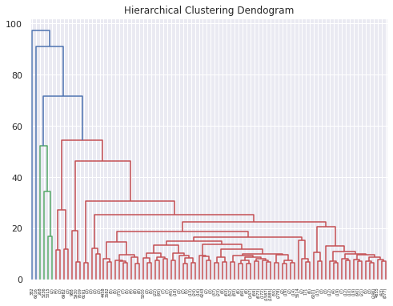

```python
plt.figure(figsize=(8,6))
dendrogram(linkage(X1_std, method='complete'),p=90, truncate_mode='lastp')
plt.ylabel('')
plt.title('Hierarchical Clustering Dendogram')
plt.show();
```

```python
agg_ss =(metrics.silhouette_score(X1_std, aclusters, metric='euclidean'))
print("The silhoutte score of the Agglomerative Clustering solution: {:4f}".format(agg_ss))
```

```
The silhoutte score of the Agglomerative Clustering solution: 0.073105
```

## GMM

Gaussian Mixture Models (GMMs) aim to find the data generating processes by assuming that the data is generated by a mixture of several Gaussian distributions.

A soft clustering model.

```python
gmm_cluster = GaussianMixture(n_components=4, random_state=123)

# Fit model
gclusters = gmm_cluster.fit_predict(X1_std)
# # Scale GMM back to unscaled values
clusters_sc = scaler1.inverse_transform(gmm_cluster.means_)
clusters_df = pd.DataFrame(clusters_sc, columns = X1.columns)
clusters_df
```

|  | investment_rounds | funding_rounds | funding_total_usd | milestones | relationships | raised_amount_usd | pre_money_valuation_usd | post_money_valuation_usd | participants | is_first_round | is_last_round | elite | 0 | 1 |
| --- | --- | --- | --- | --- | --- | --- | --- | --- | --- | --- | --- | --- | --- | --- |
| 0 | 1.555556e+00 | 2.555556 | 2.378972e+09 | 3.000000 | 2.000000 | 1.635006e+09 | 2.910383e-11 | 9.313226e-10 | 0.666667 | 1.000000 | 0.666667 | 5.555556e-01 | 0.103810 | 0.139565 |
| 1 | 2.081668e-16 | 3.174037 | 2.667904e+07 | 1.632877 | 1.811885 | 7.892831e+06 | 3.969882e+05 | 1.388846e+03 | 1.616003 | 0.619436 | 0.377967 | 4.718448e-16 | 0.064579 | 0.008794 |
| 2 | 4.163336e-16 | 1.282285 | 6.588444e+06 | 1.369618 | 2.000000 | 5.764018e+06 | 7.275958e-10 | 1.124344e+04 | 1.919992 | 1.000000 | 0.717715 | 1.744174e-01 | -0.059469 | 0.003831 |
| 3 | 6.550335e-01 | 3.241442 | 7.419742e+07 | 1.921949 | 1.916707 | 2.817576e+07 | 3.138402e+05 | 2.998956e+07 | 1.744031 | 0.709008 | 0.373138 | 6.951569e-01 | 0.077927 | -0.037177 |

```python
gmm_ss =(metrics.silhouette_score(X1_std, gclusters, metric='euclidean'))
print("The silhoutte score of the Gaussian Mixture Model solution: {:4f}".format(gmm_ss))
```

```
The silhoutte score of the Gaussian Mixture Model solution: 0.135687
```

Overall, applying DR methods prior to clustering models helps visualize the data as well as assist in reducing the components necessary to separate classes based on linear and non-linear calculations

## Mean-Shift

```python
# set the bandwidth automatically; function derives a bandwidth
# number based on an inspection of the distances among points
# in the data.
bandwidth = estimate_bandwidth(X1_std, quantile=0.9, n_samples=51)

# Declare and fit the model.
ms = MeanShift(bandwidth=bandwidth, bin_seeding=True)
ms.fit(X1_std)

# Extract cluster assignments for each data point.
labels = ms.labels_

# Coordinates of the cluster centers.
cluster_centers = ms.cluster_centers_

# Count our clusters.
n_clusters_ = len(np.unique(labels))

print("Number of estimated clusters: {}".format(n_clusters_))
```

```
Number of estimated clusters: 21
```

```python
plt.scatter(pca_2c[:, 0], pca_2c[:, 1], c=labels)

# plot the centroids
plt.scatter(
    ms.cluster_centers_[:, 0], ms.cluster_centers_[:, 1],
    s=150, marker='*',
    c='red', edgecolor='black',
    label='centroids')

plt.title('MeanShift, clusters = {}'.format(n_clusters_))
plt.show()
```

[output not shown]

```python
# Calculate silhouette_score
ms_ss = silhouette_score(X1_std, ms.labels_)
print("The silhoutte score of the Mean Shift Model solution: {:4f}".format(ms_ss))
```

```
The silhoutte score of the Mean Shift Model solution: 0.509892
```

# Density of Clustering Algorithms

```python
#silhouette_score
print('Silhouette scores are:')
print('KMeans: {:.4f}'.format(km_ss))
print('DBSCAN: {:.4f}'.format(db_ss))
print('Agglomerative Clustering: {:.4f}'.format(agg_ss))
print('Gaussian Mixture Model: {:.4f}'.format(gmm_ss))
print('Mean Shift with 21 clusters: {:.4f}'.format(ms_ss))
```

```
Silhouette scores are:
KMeans: 0.2418
DBSCAN: 0.2378
Agglomerative Clustering: 0.0731
Gaussian Mixture Model: 0.1357
Mean Shift with 21 clusters: 0.5099
```

# Summary

- Methodology was not able to clearly identify features that determine the success of a Startup
- Analyzing the clusters tends to lend credence that Startups with a high amount of investor concentration and funding are successful
- The main reasons are due to the nature of the data and timespan of the data as well as the need for greater ancillary data

# Next Steps

- Select updated data from Crunchbase SQL database depending on fees
- Assign a Target Label for IPO, Acquired and Series C or Series D
- Rerun using a Supervised Learning Classification Model
- Webscrap LinkedIn for deeper data on people
- Focus on Growth Stage Startups

```python
# Source:
    # http://blog.nextgenetics.net/?e=102
from IPython.display import HTML

HTML('''<script>
    code_show=true;
    function code_toggle() {
     if (code_show){
     $('div.input').hide();
     } else {
     $('div.input').show();
     }
     code_show = !code_show
    }
    $( document ).ready(code_toggle);
    </script>
    The raw code for this IPython notebook is by default hidden for easier reading.
    To toggle on/off the raw code, click <a href="javascript:code_toggle()">here</a>.''')
```

The raw code for this IPython notebook is by default hidden for easier reading. To toggle on/off the raw code, click here.